# 2021년 2학기 1

사망률 논문 발표

sonsungman https://sonsungman.github.io/SKKU-Preditive.m/  
09-24-2021

지난 9월 24일 Lee-Chater 모델을 활용한 논문을 발표하였다. 동료 대학원생분과 함께 했는데 그분은 앞서 연구목적과 선행연구를 발표하시고 나는 Lee-Chater 모델에 대해 발표하였다. 1차 발표는 이렇게 마무리 되었고 2차 발표때에 실제 논문상 통계청 데이터를 활용하여 Lee-Chater 모델에 모수를 추정하고 책임준비금 산출까지 진행해 볼 계획이다.

### Lee-Charter Model

Lee-Chater 모델을 1992년에 Lee와 Chater라는 두 분께서 발표하신 사망률에 관한 모형이다. 모델은 아래와 같다.

$$ln(\hat{\mu_{x}}(t)) = \alpha_{x} + \beta_{x}k_{t} + \epsilon_{x}(t)$$

$\hat{\mu_{x}}(t)$ : t 해 x세의 사력의 관측치.

$\alpha_{x}$ : 연령별 모수로 $ln(\hat{\mu_{x}}(t))$의 t에 대한 평균.

$\beta_{x}$ : 또 다른 연령별 모수로 사망률 지수 $k_{t}$의 변화에 대한 연령별 민감도 지표.

$k_{t}$ : 사망률 지수로서 시간의 흐름에 따른 사망률의 변동 추세를 나타낸 것.

$\epsilon_{x}(t)$ : 평균이 0이고 분산이 $\sigma^{2}_{\epsilon}$인 정규분포를 따르는 오차항.

사망률의 개선은 사망률 지수$k_{t}$가 시간의 경과에 따라 감소하는 것으로 확인.

### 전통적인 LC모형의 모수 추정

LC모형에서 모수는 일반적인 최소제곱법 (OLS)을 이용하여 추정.
$$\sum_{x, t} (ln(\hat{\mu_{x}}(t))-\alpha_{x} - \beta_{x}k_{t})^{2}$$
을 최소화하는 모수로 추정하되 $\hat{\alpha}_{x}$는 $ln(\hat{\mu_{x}}(t))$의 t에 대한 평균이고, $\hat{\beta}_{x}$와 $\hat{k}_{t}$는 행렬 $ln(\hat{\mu_{x}}(t))-\alpha_{x}$를 특이값 분해 후 각 행렬의 첫 번째 벡터들로부터 추정.

또한 $\hat{\beta}_{x}$와 $\hat{k}_{t}$의 유일해를 찾기 위한 조건으로 다음의 제약식이 부과.

$$\sum_{t} k_{t} = 0, 그리고 \sum_{x} \beta_{x} = 1$$
이후 사망률 지수 $\hat{k}_{t}$를 모델링하기에 앞서 사망자수의 관측치와 기대사망자수가 일치하도록 $\hat{k}_{t}$를 다시 보정하는 절차 수행.

$$\sum_{x} D_{x,t} = \sum_{x} E_{x,t} exp(\hat{\alpha}_{x} + \hat{\beta}_{x}\hat{\hat{k}_{t}})$$
$D_{x,t}$가 t해 x세의 사망자수를 그리고 $E_{x,t}$가 t해 x세의 생존자수를 나타낼 때, 위 식이 성립하도록 사망률 지수의 추정치 $\hat{K}_{t}$를 조정하는 것.

조정한 후, 사망률 지수는 ARIMA 시계열 모형으로 적합, 이로부터 사망률 지수의 미래 예측치를 추정.

### 포아송 로그-이중선형 모형

전통적 LC모형에서 특이값 분해를 통한 OLS 추정의 가장 큰 문제점 중 하나는 오차항의 등분산성 가정이다. 이는 매우 비현실적 가정으로 실제 관측된 사력의 로그변환값이 고연령에서 큰 변동을 나타내기 때문 이것의 이유는 고연령에서의 실제 사망자수가 너무 작기 때문에 발생.

Alho(2000)는 사망자수를 포아송 분포로 모델링함으로써 이 문제를 개선하고자 함.

$$D_{x,t} \sim {\sf Poisson}(E_{x,t}\mu_{x,t}) 단,\mu_{x,t} = exp(\alpha_{x}+\beta_{x}k_{t})$$

모수는 아래의 로그우도함수를 최대화하도록 추정됨.
$$L(\alpha, \beta, k) = \sum_{x,t} {D_{x,t}(\alpha_{x}+\beta_{x}k_{t}) - E_{x,t}exp(\alpha_{x}+\beta_{x}k_{t})}$$

제약식의 경우 전통적 모델과 동일.

전통적 LC모형과 달리 사망률 지수의 보정 작업을 필요로 하지 않음.ARIMA 모형에 기반한 사망률 지수 $k_{t}$의 예측을 통해 미래 사망률을 예측하는 절차 동일.

### 논문의 구성

LC모델을 활용하여 통계청 자룔를 바탕으로 추정한 미래 사력에 곰베르츠 법칙을 적용해 경험생명표를 만든다. 기존에 우리가 익히 알고 있는 국민경험생명표와 비교하여 추정 사력을 바탕으로 작성한 경험생명표 각각을 가지고 종신연금 혹은 종신 보험 상품의 책임준비금을 구한다. 순보식으로 간단하게 구할 수 있으며 이를 바탕으로 사망률 개선이 발생할 때에 책임준비금의 적립액 차이를 확인할 수 있다.

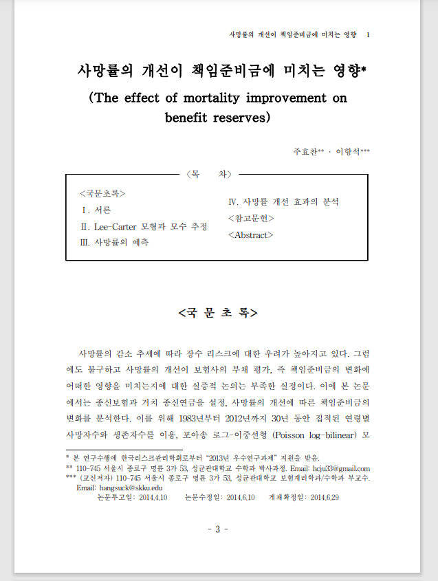

Figure 1: 논문 및 ppt 자료

[figure not shown]

Figure 2: 논문 및 ppt 자료

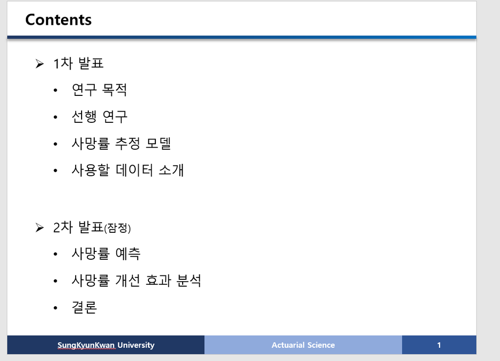

Figure 3: 논문 및 ppt 자료

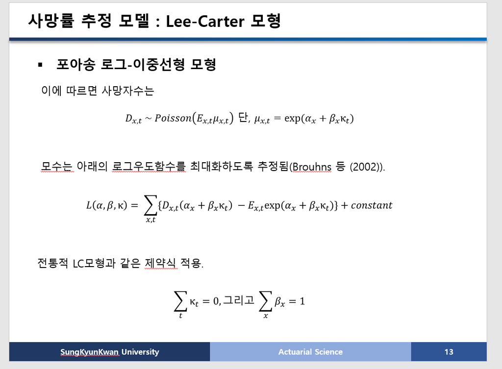

Figure 4: 논문 및 ppt 자료